# TIS PIPELINE

Sara Nicholson

2022-07-17

# TIS Pipeline

48 Fastq samples that had been demultiplexed were used in this analysis. Several samples are removed based off of read-count. Sample C5 was removed because 3 reverse primers in R1 reads in its RevComp orientation remained after cutting primers and A22 was removed due to low read count and 0 reads after further filtering and Analysis.

```r
#initializations
library(dada2)
library(ShortRead)
library(Biostrings)
```

# List demultiplexed sample fastq files

```r
samples <- list.files(path = "/home/sarakn97/WUSTL/WangL")
# Sort Forward and Reverse Reads
R1s <- sort(list.files(path = "/home/sarakn97/WUSTL/WangL", pattern = "_R1_001.fastq.gz", full.names = TRUE))
R2s <- sort(list.files(path = "/home/sarakn97/WUSTL/WangL", pattern = "_R2_001.fastq.gz", full.names = TRUE))
```

Now, Fastq sample files with less than 13 reads wil be removed from the Analysis.

```r
# Delete files with less than 13 Reads
for (x in R1s) {
  if ((countLines(x)/4) < 13) {
   unlink(x)
  }
}

for (x in R2s) {
  if ((countLines(x)/4) < 13) {
    unlink(x)
  }
}

# Remove Samples A1, A3, A4, A9, A11, A12, A14
exists <- file.exists(R1s) & file.exists(R2s)
R1s <- R1s[exists]
R2s <- R2s[exists]
```

# Identify Primers

```r
FWD <- "GCATCGATGAAGAACGCAGC"
REV <- "TCCTCCGCTTATTGATATGC"
```

# Create all orientations of primers

```r
allOrients <- function(primer) {
  require(Biostrings)
  dna <- DNAString(primer)
  orients <- c(Forward = dna, Complement = complement(dna), Reverse = reverse(dna), RevComp = reverseComplement(dna))
  return(sapply(orients, toString))
}
FWD.orients <- allOrients(FWD)
REV.orients <- allOrients(REV)
```

# filter sequences, remove those with “N”s

sequences with ambigous bases are removed prior to analysis and primer removal

```r
R1s.filtN <- file.path(path = "/home/sarakn97/WUSTL/WangL", "filtN", basename(R1s))
R2s.filtN <- file.path(path = "/home/sarakn97/WUSTL/WangL", "filtN", basename(R2s))
filterAndTrim(R1s, R1s.filtN, R2s, R2s.filtN, maxN = 0, multithread = TRUE)
```

# Count primer appearances in forward&reverse reads, considering all orientations

FWD & REV primers are seen in their reverse complement orientation in R2(reverse) $ R1(forward) reads, respectively. This is due to the varying lengths of the ITS region.

```r
primerHits <- function(primer, fn) {
  # Counts number of reads in which the primer is found
  nhits <- vcountPattern(primer, sread(readFastq(fn)), fixed = FALSE)
  return(sum(nhits>0))
}
rbind(FWD.ForwardReads = sapply(FWD.orients, primerHits, fn = R1s.filtN),
      FWD.ReverseReads = sapply(FWD.orients, primerHits, fn = R2s.filtN),
      REV.ForwardReads = sapply(REV.orients, primerHits, fn = R1s.filtN),
      REV.ReverseReads = sapply(REV.orients, primerHits, fn = R2s.filtN))
```

```
##                  Forward Complement Reverse RevComp
## FWD.ForwardReads 1510574          0       0       0
## FWD.ReverseReads       0          0       0   75053
## REV.ForwardReads       0          0       0   76890
## REV.ReverseReads 1496563          0       0       0
```

# Remove Primers using cutadapt

```r
cutadapt <- "/usr/bin/cutadapt"
# Check to see if cutadapt has been successfully identified
system2(cutadapt, args = "--version")

# Create Output files for cutadapt-ed files & define cutadapt parameters
path <- "/home/sarakn97/WUSTL/WangL"
path.cut <- file.path(path, "cutadapt")
if (!dir.exists(path.cut)) dir.create(path.cut)
R1s.cut <- file.path(path.cut, basename(R1s))
R2s.cut <- file.path(path.cut, basename(R2s))

FWD.RC <- dada2:::rc(FWD)
REV.RC <- dada2:::rc(REV)
# Trim FWD & RC of REV off of R1s
R1.flags <- paste("-g", FWD, "-a", REV.RC)
# Trim REV and the reverse-complement of FWD off of R2 (reverse reads)
R2.flags <- paste("-G", REV, "-A", FWD.RC)
# Run Cutadapt, "-n 2" required to remove both FWD & REV from reads
for(i in seq_along(R1s)) {
  system2(cutadapt, args=c(R1.flags, R2.flags, "-n", 2,
                           "-o", R1s.cut[i], "-p", R2s.cut[i], R1s.filtN[i], R2s.filtN[i]))
}
```

Count Primers Again to see if Cutadapt primer removal worked in All Orientations of REV & FWD

```r
# Notes: 3 remaining REV primers of Forward Reads in RC orientation ??
# ^^ Removed C5 to fix issue.... How do I identify the sample with remaining primers after trimming?
rbind(FWD.ForwardReads = sapply(FWD.orients, primerHits, fn = R1s.cut),
      FWD.ReverseReads = sapply(FWD.orients, primerHits, fn = R2s.cut),
      REV.ForwardReads = sapply(REV.orients, primerHits, fn = R1s.cut),
      REV.ReverseReads = sapply(REV.orients, primerHits, fn = R2s.cut))
```

```
##                  Forward Complement Reverse RevComp
## FWD.ForwardReads       0          0       0       0
## FWD.ReverseReads       0          0       0       0
## REV.ForwardReads       0          0       0       0
## REV.ReverseReads       0          0       0       0
```

# Sort lists of forward and reverse cutadapt-ed fastq files

```r
cutR1s <- sort(list.files(path.cut, pattern = "_R1_001.fastq.gz", full.names = TRUE))
cutR2s <- sort(list.files(path.cut, pattern = "_R2_001.fastq.gz", full.names = TRUE))
```

# Filter And Trim

```r
postcut.path1 <- "/home/sarakn97/WUSTL/WangL/cutadapt"
FiltR1s <- file.path(postcut.path1, "filtered", basename(cutR1s))
postcut.path2 <- "/home/sarakn97/WUSTL/WangL/cutadapt"
FiltR2s <- file.path(postcut.path2, "filtered", basename(cutR2s))
```

# Filter & Trim Reads

maxEE sets max # of expected errors allowed in read, max number of N’s is still 0 and the min length for reads is 50

```r
library(knitr)
out <- filterAndTrim(cutR1s, FiltR1s, cutR2s, FiltR2s, maxN = 0, maxEE = c(2,2), truncQ = 2, minLen = 50, rm.phix = TRUE, compress = TRUE, multithread = TRUE)
kable(head(out))
```

|  | reads.in | reads.out |
| --- | --- | --- |
| WangL_A10_TACAGCAGGA_CTCCAACTCA_S41_R1_001.fastq.gz | 93309 | 83561 |
| WangL_A13_TAGCTGGTGC_CTCCAACTCA_S44_R1_001.fastq.gz | 66 | 58 |
| WangL_A15_TTGACACTGC_GAGTTAGCTT_S46_R1_001.fastq.gz | 34031 | 31441 |
| WangL_A16_ACAACGGACT_GAGTTAGCTT_S47_R1_001.fastq.gz | 43845 | 32095 |
| WangL_A17_CCACTTCCGT_GAGTTAGCTT_S48_R1_001.fastq.gz | 75417 | 68672 |
| WangL_A18_CATCTATGTG_GAGTTAGCTT_S49_R1_001.fastq.gz | 36524 | 29977 |

# Inspect Read Quality profiles

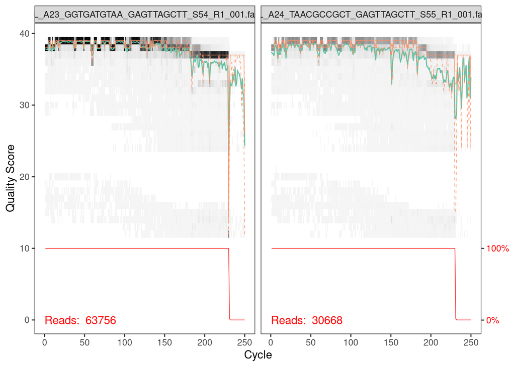

```r
# Would not work before FilterAndTrim bc some reads in samples had 0 length
plotQualityProfile(FiltR1s[10:11])
```

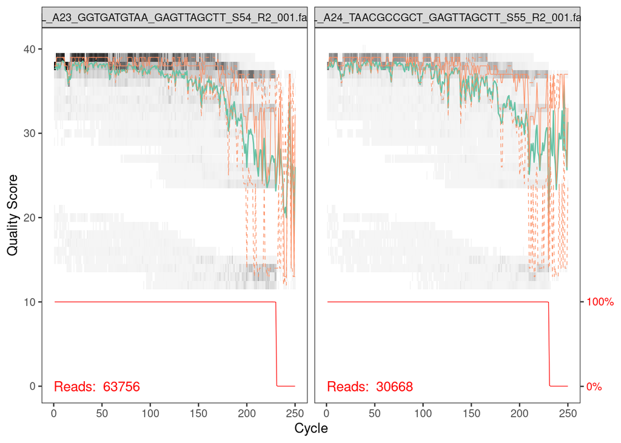

```r
plotQualityProfile(FiltR2s[10:11])
```

# Learn the Error Rates

```r
errR1 <- learnErrors(FiltR1s, multithread = TRUE)
```

```
## 107373483 total bases in 466812 reads from 12 samples will be used for learning the error rates.
```

```r
errR2 <- learnErrors(FiltR1s, multithread = TRUE)
```

```
## 107373483 total bases in 466812 reads from 12 samples will be used for learning the error rates.
```

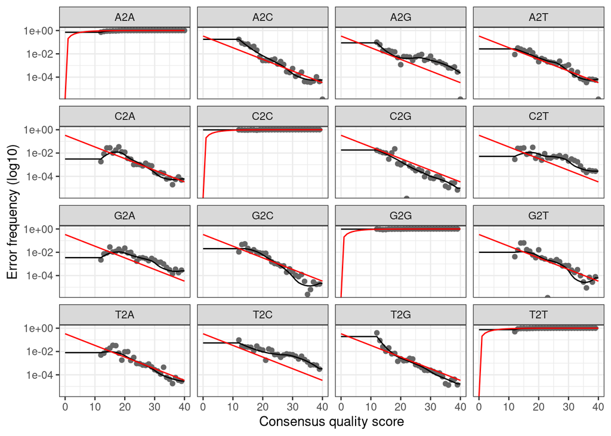

```r
# Visualize estimated error rates, all looks good
plotErrors(errR1, nominalQ = TRUE)
```

# Dereplicate identical reads

```r
derepR1s <- derepFastq(FiltR1s, verbose = TRUE)
derepR2s <- derepFastq(FiltR2s, verbose = TRUE)
```

# Extract Sample Names

```r
get.sample.name <- function(fname) (basename(fname))
remove.ext <- function(fname) (tools::file_path_sans_ext(fname, compression=TRUE))
sample.names <- unname(sapply(FiltR1s, get.sample.name))
sample.names <- unname(sapply(sample.names, remove.ext))
sample.names <- data.frame("data" = sample.names)
sample.names <- substr(sample.names$data,1, nchar(sample.names$data)-7)
sample.names <- as.character(sample.names)

# Name the derep-class objects by sample names
names(derepR1s) <- sample.names
names(derepR2s) <- sample.names
```

# Sample Inference, core sample inference algorithm

```r
dadaR1s <- dada(derepR1s, err = errR1, multithread = TRUE)
```

```
## Sample 1 - 83561 reads in 3272 unique sequences.
## Sample 2 - 58 reads in 10 unique sequences.
## Sample 3 - 31441 reads in 2169 unique sequences.
## Sample 4 - 32095 reads in 2877 unique sequences.
## Sample 5 - 68672 reads in 5528 unique sequences.
## Sample 6 - 29977 reads in 2426 unique sequences.
## Sample 7 - 38521 reads in 7702 unique sequences.
## Sample 8 - 39936 reads in 2014 unique sequences.
## Sample 9 - 14042 reads in 1837 unique sequences.
## Sample 10 - 63756 reads in 4072 unique sequences.
## Sample 11 - 30668 reads in 3541 unique sequences.
## Sample 12 - 34085 reads in 3306 unique sequences.
## Sample 13 - 44680 reads in 2545 unique sequences.
## Sample 14 - 41226 reads in 1911 unique sequences.
## Sample 15 - 23637 reads in 3464 unique sequences.
## Sample 16 - 35339 reads in 3394 unique sequences.
## Sample 17 - 17491 reads in 2131 unique sequences.
## Sample 18 - 22416 reads in 2346 unique sequences.
## Sample 19 - 24437 reads in 2975 unique sequences.
## Sample 20 - 15310 reads in 3488 unique sequences.
## Sample 21 - 455 reads in 58 unique sequences.
## Sample 22 - 37729 reads in 3202 unique sequences.
## Sample 23 - 36704 reads in 6545 unique sequences.
## Sample 24 - 51741 reads in 2448 unique sequences.
## Sample 25 - 19863 reads in 1830 unique sequences.
## Sample 26 - 21987 reads in 1676 unique sequences.
## Sample 27 - 43 reads in 26 unique sequences.
## Sample 28 - 32102 reads in 10552 unique sequences.
## Sample 29 - 30228 reads in 2600 unique sequences.
## Sample 30 - 15926 reads in 5511 unique sequences.
## Sample 31 - 9159 reads in 1974 unique sequences.
## Sample 32 - 30362 reads in 8614 unique sequences.
## Sample 33 - 35616 reads in 1633 unique sequences.
## Sample 34 - 35406 reads in 2586 unique sequences.
## Sample 35 - 25343 reads in 1361 unique sequences.
## Sample 36 - 36927 reads in 1739 unique sequences.
## Sample 37 - 23811 reads in 2428 unique sequences.
## Sample 38 - 31176 reads in 2036 unique sequences.
## Sample 39 - 18850 reads in 1225 unique sequences.
```

```r
dadaR2s <- dada(derepR2s, err = errR2, multithread = TRUE)
```

```
## Sample 1 - 83561 reads in 7738 unique sequences.
## Sample 2 - 58 reads in 14 unique sequences.
## Sample 3 - 31441 reads in 6057 unique sequences.
## Sample 4 - 32095 reads in 7713 unique sequences.
## Sample 5 - 68672 reads in 9360 unique sequences.
## Sample 6 - 29977 reads in 10475 unique sequences.
## Sample 7 - 38521 reads in 8190 unique sequences.
## Sample 8 - 39936 reads in 4845 unique sequences.
## Sample 9 - 14042 reads in 5998 unique sequences.
## Sample 10 - 63756 reads in 18587 unique sequences.
## Sample 11 - 30668 reads in 7564 unique sequences.
## Sample 12 - 34085 reads in 6986 unique sequences.
## Sample 13 - 44680 reads in 28162 unique sequences.
## Sample 14 - 41226 reads in 2507 unique sequences.
## Sample 15 - 23637 reads in 9792 unique sequences.
## Sample 16 - 35339 reads in 10193 unique sequences.
## Sample 17 - 17491 reads in 6528 unique sequences.
## Sample 18 - 22416 reads in 11470 unique sequences.
## Sample 19 - 24437 reads in 5598 unique sequences.
## Sample 20 - 15310 reads in 7691 unique sequences.
## Sample 21 - 455 reads in 151 unique sequences.
## Sample 22 - 37729 reads in 3608 unique sequences.
## Sample 23 - 36704 reads in 8913 unique sequences.
## Sample 24 - 51741 reads in 7228 unique sequences.
## Sample 25 - 19863 reads in 7962 unique sequences.
## Sample 26 - 21987 reads in 13636 unique sequences.
## Sample 27 - 43 reads in 31 unique sequences.
## Sample 28 - 32102 reads in 13749 unique sequences.
## Sample 29 - 30228 reads in 6914 unique sequences.
## Sample 30 - 15926 reads in 5763 unique sequences.
## Sample 31 - 9159 reads in 3175 unique sequences.
## Sample 32 - 30362 reads in 5583 unique sequences.
## Sample 33 - 35616 reads in 6116 unique sequences.
## Sample 34 - 35406 reads in 5747 unique sequences.
## Sample 35 - 25343 reads in 5671 unique sequences.
## Sample 36 - 36927 reads in 12203 unique sequences.
## Sample 37 - 23811 reads in 10505 unique sequences.
## Sample 38 - 31176 reads in 8355 unique sequences.
## Sample 39 - 18850 reads in 2243 unique sequences.
```

# Merge Paired Reads

```r
mergers <- mergePairs(dadaR1s, derepR1s, dadaR2s, derepR2s, verbose=TRUE)
```

# Construct Sequence Table (ASV)

```r
seqtab <- makeSequenceTable(mergers)
dim(seqtab)
```

```
## [1]  39 733
```

# Remove Chimeras

```r
# Identified 191 bimeras out of 734 input sequences.
seqtab.nochim <- removeBimeraDenovo(seqtab, method="consensus", multithread=TRUE, verbose=TRUE)
```

```
## Identified 191 bimeras out of 733 input sequences.
```

```r
# inspect distribution of seq lenghts
table(nchar(getSequences(seqtab.nochim)))
```

```
##
##  70 194 231 234 245 251 258 271 275 288 290 292 293 294 296 297 298 299 300 301
##   1   1   1   1   1   1   1   1   1   1   1   1   2   2  13   7  17   1   1   2
## 302 303 304 305 306 307 308 309 310 311 312 313 314 315 316 317 318 319 320 324
##  12   4   2   1   5   2   5   1   6   1   7   6   4   3   5   2   1   4   3  12
## 325 326 327 329 331 332 333 334 335 336 337 338 339 340 341 342 344 345 346 347
##   5   1   1   5   8   6   3   6  15   7   3   4   9   2   7   5   4   6   1   5
## 348 349 350 351 352 353 354 355 356 357 358 359 360 361 362 363 364 365 366 367
##   5   6  13   5   6   8   5   9   4   3   6   1   8   2   5   6   7  14   7   4
## 369 370 371 372 373 374 375 376 377 378 379 380 381 382 383 385 386 387 388 390
##   9   1   7  18  12   8   3  11   1   3   1   2   3   1   3   1   1   4   3   6
## 391 394 397 398 401 402 403 406 411 421 422 423 425 426 427 428 435 436 437 438
##   5  21   2   5   1   1   2   1   1   2   3   1   2   1   5   3   2   2   1   9
## 439
##   4
```

# Track Reads through Pipeline

```r
getN <- function(x) sum(getUniques(x))
track <- cbind(out, sapply(dadaR1s, getN), sapply(dadaR2s, getN), sapply(mergers, getN), rowSums(seqtab.nochim))
colnames(track) <- c("input", "filtered", "denoisedR1", "denoisedR2", "merged", "nochim")
rownames(track) <- sample.names
kable(head(track))
```

|  | input | filtered | denoisedR1 | denoisedR2 | merged | nochim |
| --- | --- | --- | --- | --- | --- | --- |
| WangL_A10_TACAGCAGGA_CTCCAACTCA_S41 | 93309 | 83561 | 83522 | 80504 | 79311 | 79123 |
| WangL_A13_TAGCTGGTGC_CTCCAACTCA_S44 | 66 | 58 | 54 | 53 | 53 | 53 |
| WangL_A15_TTGACACTGC_GAGTTAGCTT_S46 | 34031 | 31441 | 31414 | 31431 | 24351 | 23967 |
| WangL_A16_ACAACGGACT_GAGTTAGCTT_S47 | 43845 | 32095 | 31841 | 32054 | 21451 | 21449 |
| WangL_A17_CCACTTCCGT_GAGTTAGCTT_S48 | 75417 | 68672 | 68621 | 68656 | 56268 | 55910 |
| WangL_A18_CATCTATGTG_GAGTTAGCTT_S49 | 36524 | 29977 | 29963 | 29970 | 19730 | 19690 |

# Assign Taxonomy

```r
unite.ref <- "/home/sarakn97/WUSTL/sh_general_release_10.05.2021"
taxa.gen <- assignTaxonomy(seqtab.nochim, unite.ref, multithread = TRUE, tryRC = TRUE)
```

```
## UNITE fungal taxonomic reference detected.
```

```r
taxatab <- taxa.gen  # Removing sequence rownames for display only
rownames(taxatab) <- NULL
kable(head(taxatab))
```

| Kingdom | Phylum | Class | Order | Family | Genus | Species |
| --- | --- | --- | --- | --- | --- | --- |
| k__Fungi | p__Ascomycota | c__Saccharomycetes | o__Saccharomycetales | f__Saccharomycetales_fam_Incertae_sedis | g__Candida | s__albicans |
| k__Fungi | p__Ascomycota | c__Saccharomycetes | o__Saccharomycetales | f__Saccharomycetaceae | g__Saccharomyces | NA |
| k__Fungi | p__Ascomycota | c__Dothideomycetes | o__Pleosporales | f__Didymellaceae | NA | NA |
| k__Fungi | p__Ascomycota | c__Saccharomycetes | o__Saccharomycetales | f__Phaffomycetaceae | g__Cyberlindnera | s__jadinii |
| k__Fungi | p__Ascomycota | c__Saccharomycetes | o__Saccharomycetales | f__Phaffomycetaceae | g__Cyberlindnera | s__jadinii |
| k__Fungi | p__Ascomycota | c__Saccharomycetes | o__Saccharomycetales | f__Debaryomycetaceae | g__Debaryomyces | NA |

# Resulting ASV table with taxonomy

The sequences are in the first column and are hidden in the table displaying taxonomy and samples of the variants.

```r
df.combined <- cbind(taxatab, t(seqtab.nochim))
write.csv(df.combined,"/home/sarakn97/WUSTL/WangL/ASV.csv")
library(data.table)
dat <- fread("/home/sarakn97/WUSTL/WangL/ASV.csv", select = c(2:9), nrows = 1)
kable(dat)
```

| Kingdom | Phylum | Class | Order | Family | Genus | Species | WangL_A10_TACAGCAGGA_CTCCAACTCA_S41 |
| --- | --- | --- | --- | --- | --- | --- | --- |
| k__Fungi | p__Ascomycota | c__Saccharomycetes | o__Saccharomycetales | f__Saccharomycetales_fam_Incertae_sedis | g__Candida | s__albicans | 956 |